# Tiny Data Science Project

```python
import pandas as pd
import matplotlib.pyplot as plt
import scipy.stats as stats
import seaborn as sns
```

```python
# Upload the dataset
crimedata = pd.DataFrame(pd.read_csv("MPS Borough Level Crime (Historical).csv"))
```

```python
# Get the count of null values in the entire DataFrame
total_null = crimedata.isnull().sum().sum()
# Display total null count
print(f"Total null values: {total_null}")
```

```
Total null values: 0
```

Focusing on the crime trends for 2017-2023

Note: Repeated codes aren't explained

```python
# To examine the crime trends, the first 3 columns are not needed but one is kept for practicality
crimeall = crimedata.drop(columns=['MajorText', 'MinorText'])
```

```python
# Renaming the borough column
crimeall1 = crimeall.rename(columns = {'LookUp_BoroughName' : 'Borough'})
# Grouping the borough column to eliminate multiple entries of the same borough
crimeall1 = crimeall1.groupby('Borough', as_index=False).sum()
```

```python
# Filtering the dataframe to derive the required timeframe 2017 to the latest data, so 202109
crimeall1.drop(crimeall1.columns[1:90], axis=1, inplace=True)
```

```python
# Uploading data past 2021 09
crime_post = pd.DataFrame(pd.read_csv('MPS Borough Level Crime (most recent 24 months).csv'))
```

```python
# Dropping columns
crime_post = crime_post.drop(columns=['MajorText', 'MinorText'])
```

```python
crime_post = crime_post.rename(columns = {'LookUp_BoroughName' : 'Borough'})

# group the boroughs columns

crime_post = crime_post.groupby('Borough', as_index=False).sum()
```

```python
# Merging the two crimes on the columns 'Borough'

crimedf = pd.merge(crimeall1, crime_post, how='left', on='Borough')
```

```python
# Turning the merged dataframe into a pivot table with a new column representing dates and each borough being its own column

crimedf1 = pd.pivot_table(crimedf, values=['201709','201710','201711','201712','201801','201802','201803','201804','201805','201806','201807','201808','201809','201810','201811','201812','201901','201902','201903','201904','201905','201906','201907','201908','201909','201910','201911','201912','202001','202002','202003','202004','202005','202006','202007','202008','202009','202010','202011','202012','202101','202102','202103','202104','202105','202106','202107','202108','202109','202110','202111','202112','202201','202202','202203','202204','202205','202206','202207','202208','202208','202209','202210','202211','202212','202301','202302','202303','202304','202305','202306','202307','202308','202309'],columns=['Borough'],aggfunc='sum')
```

```python
# Changing the date format ot a more clear one, eg. 201709 is turned to September - 2019 to avoid confusion

crimedf1['Date'] = pd.to_datetime(crimedf1.index,format='%Y%m').strftime('%b-%Y')
crimedf1.set_index('Date', inplace=True)
```

```python
crimedf1.reset_index()
```

| Borough | Date | Barking and Dagenham | Barnet | Bexley | Brent | Bromley | Camden | Croydon | Ealing | Enfield | ... | Merton | Newham | Redbridge | Richmond upon Thames | Southwark | Sutton | Tower Hamlets | Waltham Forest | Wandsworth | Westminster |
| --- | --- | --- | --- | --- | --- | --- | --- | --- | --- | --- | --- | --- | --- | --- | --- | --- | --- | --- | --- | --- | --- |
| 0 | Sep-2017 | 1550 | 2151 | 1298 | 2536 | 1808 | 3296 | 2521 | 2245 | 2050 | ... | 1182 | 2880 | 2048 | 1182 | 2925 | 1017 | 2610 | 1888 | 2056 | 4734 |
| 1 | Oct-2017 | 1637 | 2413 | 1424 | 2789 | 1843 | 3609 | 2528 | 2649 | 2299 | ... | 1146 | 3153 | 2210 | 1157 | 2977 | 1076 | 2976 | 2098 | 2221 | 4884 |
| 2 | Nov-2017 | 1524 | 2463 | 1346 | 2673 | 2003 | 3414 | 2565 | 2555 | 2288 | ... | 1172 | 3155 | 2002 | 1143 | 3163 | 977 | 2593 | 1981 | 2228 | 4898 |
| 3 | Dec-2017 | 1462 | 2084 | 1184 | 2432 | 1817 | 2956 | 2545 | 2118 | 2052 | ... | 1213 | 2804 | 1922 | 980 | 2647 | 924 | 2345 | 1710 | 2187 | 5189 |
| 4 | Jan-2018 | 1507 | 2258 | 1267 | 2520 | 2006 | 3099 | 2606 | 2299 | 2198 | ... | 1165 | 2967 | 2109 | 1003 | 2838 | 1049 | 2644 | 1903 | 2177 | 4828 |
| ... | ... | ... | ... | ... | ... | ... | ... | ... | ... | ... | ... | ... | ... | ... | ... | ... | ... | ... | ... | ... | ... |
| 68 | May-2023 | 1994 | 2479 | 1433 | 2801 | 2053 | 3505 | 2854 | 2878 | 2573 | ... | 1201 | 3211 | 2193 | 1078 | 3381 | 1080 | 3033 | 1900 | 2459 | 7329 |
| 69 | Jun-2023 | 2007 | 2489 | 1415 | 2896 | 2074 | 3580 | 3121 | 2761 | 2561 | ... | 1268 | 3467 | 2172 | 1014 | 3598 | 1214 | 3114 | 2086 | 2460 | 7615 |
| 70 | Jul-2023 | 1987 | 2589 | 1385 | 2736 | 2031 | 3480 | 3091 | 2890 | 2507 | ... | 1267 | 3268 | 2073 | 1051 | 3380 | 1196 | 3258 | 2055 | 2509 | 7788 |
| 71 | Aug-2023 | 1912 | 2347 | 1404 | 2558 | 2030 | 3214 | 2936 | 2725 | 2343 | ... | 1115 | 3301 | 2060 | 1091 | 3182 | 1019 | 3060 | 1985 | 2249 | 6948 |
| 72 | Sep-2023 | 1955 | 2359 | 1417 | 2602 | 2029 | 3291 | 3033 | 2910 | 2510 | ... | 1252 | 3346 | 2127 | 1047 | 3337 | 1099 | 3122 | 1991 | 2254 | 6693 |

73 rows × 34 columns

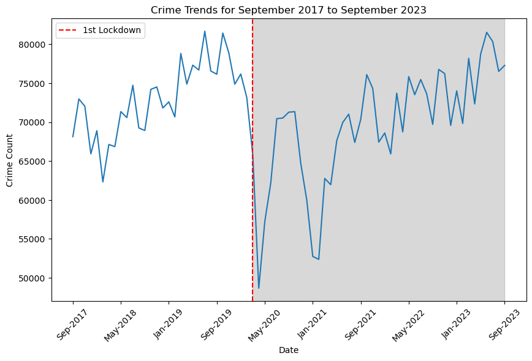

```python
# monthly_total represents the sum of each row for all columns
monthly_total = crimedf1.sum(axis=1)

# Plotting the figure using lineplot
plt.figure(figsize=(10, 6))
sns.lineplot(x='Date', y=monthly_total, data=crimedf1)
plt.title('Crime Trends for September 2017 to September 2023')
plt.xlabel('Date')
plt.ylabel('Crime Count')

# Plotting the line when the 1st lockdown happened
plt.axvline(x='Mar-2020', color='red', linestyle='--', label='1st Lockdown')
# Plotting the shade area representing the period that's been impacted by COVID-19
plt.axvspan('Mar-2020', 'Sep-2023', alpha=0.3, color='gray')

plt.xticks(rotation=45)
plt.gca().xaxis.set_major_locator(plt.MaxNLocator(10))
plt.legend()
plt.show()
```

```python
crimedf1.reset_index()
```

| Borough | Date | Barking and Dagenham | Barnet | Bexley | Brent | Bromley | Camden | Croydon | Ealing | Enfield | ... | Merton | Newham | Redbridge | Richmond upon Thames | Southwark | Sutton | Tower Hamlets | Waltham Forest | Wandsworth | Westminster |
| --- | --- | --- | --- | --- | --- | --- | --- | --- | --- | --- | --- | --- | --- | --- | --- | --- | --- | --- | --- | --- | --- |
| 0 | Sep-2017 | 1550 | 2151 | 1298 | 2536 | 1808 | 3296 | 2521 | 2245 | 2050 | ... | 1182 | 2880 | 2048 | 1182 | 2925 | 1017 | 2610 | 1888 | 2056 | 4734 |
| 1 | Oct-2017 | 1637 | 2413 | 1424 | 2789 | 1843 | 3609 | 2528 | 2649 | 2299 | ... | 1146 | 3153 | 2210 | 1157 | 2977 | 1076 | 2976 | 2098 | 2221 | 4884 |
| 2 | Nov-2017 | 1524 | 2463 | 1346 | 2673 | 2003 | 3414 | 2565 | 2555 | 2288 | ... | 1172 | 3155 | 2002 | 1143 | 3163 | 977 | 2593 | 1981 | 2228 | 4898 |
| 3 | Dec-2017 | 1462 | 2084 | 1184 | 2432 | 1817 | 2956 | 2545 | 2118 | 2052 | ... | 1213 | 2804 | 1922 | 980 | 2647 | 924 | 2345 | 1710 | 2187 | 5189 |
| 4 | Jan-2018 | 1507 | 2258 | 1267 | 2520 | 2006 | 3099 | 2606 | 2299 | 2198 | ... | 1165 | 2967 | 2109 | 1003 | 2838 | 1049 | 2644 | 1903 | 2177 | 4828 |
| ... | ... | ... | ... | ... | ... | ... | ... | ... | ... | ... | ... | ... | ... | ... | ... | ... | ... | ... | ... | ... | ... |
| 68 | May-2023 | 1994 | 2479 | 1433 | 2801 | 2053 | 3505 | 2854 | 2878 | 2573 | ... | 1201 | 3211 | 2193 | 1078 | 3381 | 1080 | 3033 | 1900 | 2459 | 7329 |
| 69 | Jun-2023 | 2007 | 2489 | 1415 | 2896 | 2074 | 3580 | 3121 | 2761 | 2561 | ... | 1268 | 3467 | 2172 | 1014 | 3598 | 1214 | 3114 | 2086 | 2460 | 7615 |
| 70 | Jul-2023 | 1987 | 2589 | 1385 | 2736 | 2031 | 3480 | 3091 | 2890 | 2507 | ... | 1267 | 3268 | 2073 | 1051 | 3380 | 1196 | 3258 | 2055 | 2509 | 7788 |
| 71 | Aug-2023 | 1912 | 2347 | 1404 | 2558 | 2030 | 3214 | 2936 | 2725 | 2343 | ... | 1115 | 3301 | 2060 | 1091 | 3182 | 1019 | 3060 | 1985 | 2249 | 6948 |
| 72 | Sep-2023 | 1955 | 2359 | 1417 | 2602 | 2029 | 3291 | 3033 | 2910 | 2510 | ... | 1252 | 3346 | 2127 | 1047 | 3337 | 1099 | 3122 | 1991 | 2254 | 6693 |

73 rows × 34 columns

```python
crimedf1
```

| Borough Date | Barking and Dagenham | Barnet | Bexley | Brent | Bromley | Camden | Croydon | Ealing | Enfield | Greenwich | ... | Merton | Newham | Redbridge | Richmond upon Thames | Southwark | Sutton | Tower Hamlets | Waltham Forest | Wandsworth | Westminster |
| --- | --- | --- | --- | --- | --- | --- | --- | --- | --- | --- | --- | --- | --- | --- | --- | --- | --- | --- | --- | --- | --- |
| Sep-2017 | 1550 | 2151 | 1298 | 2536 | 1808 | 3296 | 2521 | 2245 | 2050 | 2116 | ... | 1182 | 2880 | 2048 | 1182 | 2925 | 1017 | 2610 | 1888 | 2056 | 4734 |
| Oct-2017 | 1637 | 2413 | 1424 | 2789 | 1843 | 3609 | 2528 | 2649 | 2299 | 2322 | ... | 1146 | 3153 | 2210 | 1157 | 2977 | 1076 | 2976 | 2098 | 2221 | 4884 |
| Nov-2017 | 1524 | 2463 | 1346 | 2673 | 2003 | 3414 | 2565 | 2555 | 2288 | 2040 | ... | 1172 | 3155 | 2002 | 1143 | 3163 | 977 | 2593 | 1981 | 2228 | 4898 |
| Dec-2017 | 1462 | 2084 | 1184 | 2432 | 1817 | 2956 | 2545 | 2118 | 2052 | 1988 | ... | 1213 | 2804 | 1922 | 980 | 2647 | 924 | 2345 | 1710 | 2187 | 5189 |
| Jan-2018 | 1507 | 2258 | 1267 | 2520 | 2006 | 3099 | 2606 | 2299 | 2198 | 2055 | ... | 1165 | 2967 | 2109 | 1003 | 2838 | 1049 | 2644 | 1903 | 2177 | 4828 |
| ... | ... | ... | ... | ... | ... | ... | ... | ... | ... | ... | ... | ... | ... | ... | ... | ... | ... | ... | ... | ... | ... |
| May-2023 | 1994 | 2479 | 1433 | 2801 | 2053 | 3505 | 2854 | 2878 | 2573 | 2597 | ... | 1201 | 3211 | 2193 | 1078 | 3381 | 1080 | 3033 | 1900 | 2459 | 7329 |
| Jun-2023 | 2007 | 2489 | 1415 | 2896 | 2074 | 3580 | 3121 | 2761 | 2561 | 2699 | ... | 1268 | 3467 | 2172 | 1014 | 3598 | 1214 | 3114 | 2086 | 2460 | 7615 |
| Jul-2023 | 1987 | 2589 | 1385 | 2736 | 2031 | 3480 | 3091 | 2890 | 2507 | 2581 | ... | 1267 | 3268 | 2073 | 1051 | 3380 | 1196 | 3258 | 2055 | 2509 | 7788 |
| Aug-2023 | 1912 | 2347 | 1404 | 2558 | 2030 | 3214 | 2936 | 2725 | 2343 | 2311 | ... | 1115 | 3301 | 2060 | 1091 | 3182 | 1019 | 3060 | 1985 | 2249 | 6948 |
| Sep-2023 | 1955 | 2359 | 1417 | 2602 | 2029 | 3291 | 3033 | 2910 | 2510 | 2516 | ... | 1252 | 3346 | 2127 | 1047 | 3337 | 1099 | 3122 | 1991 | 2254 | 6693 |

73 rows × 33 columns

Filtering to include all data from the years 2020 and 2021

covidy = crimedf1.filter(regex='^2020|^2021', axis=0)

The above code was used initially but this wouldn't show the dataset had to be uploaded again:

```python
cov = pd.DataFrame(pd.read_csv("MPS Borough Level Crime (Historical).csv"))
```

```python
cov.drop(columns=['MajorText', 'MinorText'])
```

|  | LookUp_BoroughName | 201004 | 201005 | 201006 | 201007 | 201008 | 201009 | 201010 | 201011 | 201012 | ... | 202012 | 202101 | 202102 | 202103 | 202104 | 202105 | 202106 | 202107 | 202108 | 202109 |
| --- | --- | --- | --- | --- | --- | --- | --- | --- | --- | --- | --- | --- | --- | --- | --- | --- | --- | --- | --- | --- | --- |
| 0 | Barking and Dagenham | 6 | 5 | 11 | 10 | 6 | 6 | 13 | 13 | 14 | ... | 2 | 4 | 6 | 4 | 6 | 6 | 5 | 4 | 12 | 5 |
| 1 | Barking and Dagenham | 208 | 193 | 227 | 220 | 204 | 163 | 199 | 178 | 138 | ... | 110 | 100 | 104 | 80 | 99 | 128 | 141 | 130 | 144 | 111 |
| 2 | Barking and Dagenham | 49 | 58 | 59 | 47 | 46 | 51 | 52 | 62 | 49 | ... | 24 | 21 | 18 | 14 | 12 | 30 | 24 | 21 | 29 | 27 |
| 3 | Barking and Dagenham | 118 | 102 | 124 | 137 | 153 | 136 | 116 | 140 | 105 | ... | 91 | 70 | 90 | 71 | 75 | 81 | 66 | 61 | 87 | 62 |
| 4 | Barking and Dagenham | 9 | 6 | 5 | 12 | 9 | 7 | 11 | 11 | 4 | ... | 13 | 12 | 11 | 12 | 9 | 9 | 7 | 6 | 11 | 19 |
| ... | ... | ... | ... | ... | ... | ... | ... | ... | ... | ... | ... | ... | ... | ... | ... | ... | ... | ... | ... | ... | ... |
| 1722 | Westminster | 231 | 215 | 204 | 213 | 167 | 197 | 197 | 204 | 287 | ... | 238 | 118 | 129 | 150 | 156 | 265 | 218 | 218 | 244 | 267 |
| 1723 | Westminster | 79 | 54 | 46 | 41 | 55 | 82 | 87 | 53 | 25 | ... | 40 | 53 | 34 | 51 | 39 | 41 | 34 | 56 | 46 | 61 |
| 1724 | Westminster | 0 | 1 | 0 | 0 | 0 | 0 | 0 | 0 | 0 | ... | 1 | 0 | 1 | 0 | 0 | 1 | 0 | 1 | 2 | 0 |
| 1725 | Westminster | 271 | 283 | 289 | 328 | 288 | 270 | 319 | 287 | 279 | ... | 198 | 134 | 129 | 174 | 220 | 260 | 317 | 416 | 376 | 325 |
| 1726 | Westminster | 295 | 322 | 356 | 346 | 312 | 316 | 297 | 280 | 264 | ... | 441 | 355 | 383 | 481 | 506 | 539 | 612 | 690 | 621 | 627 |

1727 rows × 139 columns

```python
covlock = cov.rename(columns = {'LookUp_BoroughName' : 'Borough'})
covlock = covlock.groupby('Borough', as_index=True).sum()
```

```python
covidy = covlock.filter(regex='^2020|^2021', axis=1)
```

```python
covid = pd.pivot_table(covidy, values=['202001','202002','202003','202004','202005','202006','202007','202008','202009','202010','202011','202012','202101','202102','202103','202104','202105','202106','202107','202108','202109'],columns=['Borough'],aggfunc='sum')
```

```python
covid['Date'] = pd.to_datetime(covid.index,format='%Y%m').strftime('%b-%Y')
covid.set_index('Date', inplace=True)
```

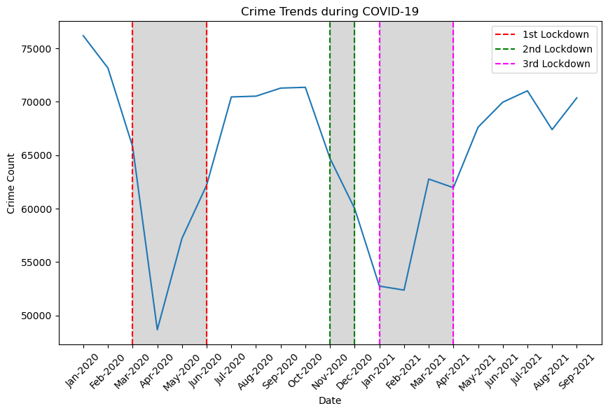

[output not shown]

[figure not shown]

```python
monthly_total = covid.sum(axis=1)

plt.figure(figsize=(10, 6))
sns.lineplot(x='Date', y=monthly_total, data=covid)
plt.title('Crime Trends during COVID-19')
plt.xlabel('Date')
plt.ylabel('Crime Count')

# Plotting the lines representing the start and end dates of each lockdown
plt.axvline(x='Mar-2020', color='red', linestyle='--', label='1st Lockdown')
plt.axvline(x='Jun-2020', color='red', linestyle='--')
plt.axvline(x='Nov-2020', color='green', linestyle='--', label='2nd Lockdown')
plt.axvline(x='Dec-2020', color='green', linestyle='--')
plt.axvline(x='Jan-2021', color='magenta', linestyle='--', label='3rd Lockdown')
plt.axvline(x='Apr-2021', color='magenta', linestyle='--')

# Plotting the areas representing the periods of each lockdown
plt.axvspan('Mar-2020', 'Jun-2020', alpha=0.3, color='gray')
plt.axvspan('Nov-2020', 'Dec-2020', alpha=0.3, color='gray')
plt.axvspan('Jan-2021', 'Apr-2021', alpha=0.3, color='gray')

plt.xticks(rotation=45)
plt.legend()
plt.show()
plt.axvspan('Mar-2020', 'Sep-2023', alpha=0.3, color='gray')  # Change the dates to match the x-values of the vertical lines

plt.xticks(rotation=45)
plt.legend()
plt.show()
```

```python
# Creating a dataframe that has a 1 for the months that lockdown was enforced and a 0 for the months that it wasn't.
# Look in the references of the report for the source of this data

lockdown_dates = pd.DataFrame(
                    {"Date" : ['202001','202002','202003','202004','202005','202006','202007','202008','202009','202010','202011','202012','202101','202102','202103','202104','202105','202106','202107','202108','202109'],
                     "Lockdown" : ['0','0','1','1','1','1','0','0','0','0','1','0','1','1','0','0','0','0','0','0','0']})
lockdown_dates
```

|  | Date | Lockdown |
| --- | --- | --- |
| 0 | 202001 | 0 |
| 1 | 202002 | 0 |
| 2 | 202003 | 1 |
| 3 | 202004 | 1 |
| 4 | 202005 | 1 |
| 5 | 202006 | 1 |
| 6 | 202007 | 0 |
| 7 | 202008 | 0 |
| 8 | 202009 | 0 |
| 9 | 202010 | 0 |
| 10 | 202011 | 1 |
| 11 | 202012 | 0 |
| 12 | 202101 | 1 |
| 13 | 202102 | 1 |
| 14 | 202103 | 0 |
| 15 | 202104 | 0 |
| 16 | 202105 | 0 |
| 17 | 202106 | 0 |
| 18 | 202107 | 0 |
| 19 | 202108 | 0 |
| 20 | 202109 | 0 |

```python
lockdown_dates.set_index('Date', inplace=True)
```

```python
lockdown_dates["Date"] = pd.to_datetime(lockdown_dates.index,format='%Y%m').strftime('%b-%Y')
lockdown_dates.set_index('Date', inplace=True)
```

```python
lockdown_dates.reset_index()
```

|  | Date | Lockdown |
| --- | --- | --- |
| 0 | Jan-2020 | 0 |
| 1 | Feb-2020 | 0 |
| 2 | Mar-2020 | 1 |
| 3 | Apr-2020 | 1 |
| 4 | May-2020 | 1 |
| 5 | Jun-2020 | 1 |
| 6 | Jul-2020 | 0 |
| 7 | Aug-2020 | 0 |
| 8 | Sep-2020 | 0 |
| 9 | Oct-2020 | 0 |
| 10 | Nov-2020 | 1 |
| 11 | Dec-2020 | 0 |
| 12 | Jan-2021 | 1 |
| 13 | Feb-2021 | 1 |
| 14 | Mar-2021 | 0 |
| 15 | Apr-2021 | 0 |
| 16 | May-2021 | 0 |
| 17 | Jun-2021 | 0 |
| 18 | Jul-2021 | 0 |
| 19 | Aug-2021 | 0 |
| 20 | Sep-2021 | 0 |

```python
# Feature Engineering:
# Creating a column in the covid dataframe containing
# the sum of the crime counts as a column

covid['Crime_Count']=monthly_total
```

```python
# Filtering the dataset to contain only the sum value to avoid confusion
covl = covid.iloc[:, [33]]
```

```python
combdf2 = pd.merge(covl,lockdown_dates, how='left', on='Date')
```

```python
combdf2
```

| Date | Crime_Count | Lockdown |
| --- | --- | --- |
| Jan-2020 | 76181 | 0 |
| Feb-2020 | 73156 | 0 |
| Mar-2020 | 65803 | 1 |
| Apr-2020 | 48656 | 1 |
| May-2020 | 57209 | 1 |
| Jun-2020 | 62194 | 1 |
| Jul-2020 | 70450 | 0 |
| Aug-2020 | 70523 | 0 |
| Sep-2020 | 71278 | 0 |
| Oct-2020 | 71351 | 0 |
| Nov-2020 | 64692 | 1 |
| Dec-2020 | 59989 | 0 |
| Jan-2021 | 52741 | 1 |
| Feb-2021 | 52365 | 1 |
| Mar-2021 | 62763 | 0 |
| Apr-2021 | 61958 | 0 |
| May-2021 | 67618 | 0 |
| Jun-2021 | 69958 | 0 |
| Jul-2021 | 71024 | 0 |
| Aug-2021 | 67391 | 0 |
| Sep-2021 | 70362 | 0 |

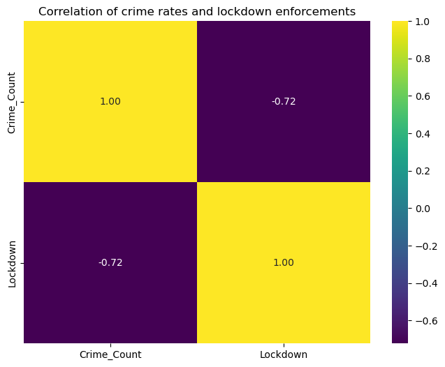

```python
plt.figure(figsize=(8, 6))
sns.heatmap(combdf2[['Crime_Count', 'Lockdown']].corr(), annot=True, cmap='viridis', fmt='.2f')
plt.title('Correlation of crime rates and lockdown enforcements')
plt.show()
```

A correlation coefficient of -0.72 between these two features indicates a strong negative linear correlation.